# Machine Learning Engineer Nanodegree

### Question 3

*How accurate would a prediction be that all female passengers and all male passengers younger than 10 survived?*  
**Hint:** Run the code cell below to see the accuracy of this prediction.

```python
print accuracy_score(outcomes, predictions)
```

```
Predictions have an accuracy of 79.35%.
```

**Answer**: *79.35%*

Adding the feature **Age** as a condition in conjunction with **Sex** improves the accuracy by a small margin more than with simply using the feature **Sex** alone. Now it's your turn: Find a series of features and conditions to split the data on to obtain an outcome prediction accuracy of at least 80%. This may require multiple features and multiple levels of conditional statements to succeed. You can use the same feature multiple times with different conditions.  
**Pclass**, **Sex**, **Age**, **SibSp**, and **Parch** are some suggested features to try.

Use the `survival_stats` function below to to examine various survival statistics.  
**Hint:** To use mulitple filter conditions, put each condition in the list passed as the last argument. Example: `["Sex == 'male'", "Age < 18"]`

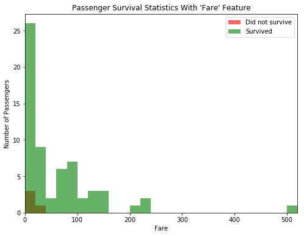

```python
vs.survival_stats(data, outcomes, 'Fare', ["Sex == 'female'","Pclass < 3","Parch == 0","SibSp == 0"])
```

After exploring the survival statistics visualization, fill in the missing code below so that the function will make your prediction.  
Make sure to keep track of the various features and conditions you tried before arriving at your final prediction model.  
**Hint:** You can start your implementation of this function using the prediction code you wrote earlier from `predictions_2`.

```python
def predictions_3(data):
    """ Model with multiple features. Makes a prediction with an accuracy of at least 80%. """

    predictions = []
    for _, passenger in data.iterrows():

        if (passenger['Sex'].lower() == 'female' and passenger['Pclass'] <= 2):
            predictions.append(1)
        elif (passenger['Age'] < 10):
            predictions.append(1)
        elif (passenger['Sex'].lower() == 'female' and passenger['Pclass'] == 3 and passenger['Fare'] <= 21):
            predictions.append(1)
        elif (passenger['Sex'].lower() == 'female'  and passenger['Parch'] == 0):
            predictions.append(1)
        else:
            predictions.append(0)

    # Return our predictions
    return pd.Series(predictions)

# Make the predictions
predictions = predictions_3(data)
```

Question 4 *Describe the steps you took to implement the final prediction model so that it got an accuracy of at least 80%. What features did you look at? Were certain features more informative than others? Which conditions did you use to split the survival outcomes in the data? How accurate are your predictions?*  
**Hint:** Run the code cell below to see the accuracy of your predictions.

```python
print accuracy_score(outcomes, predictions)
```

```
Predictions have an accuracy of 81.14%.
```

**Answer**: *I tried to look at all features and combination of features to get the best prediction possible. Everything I did was based primarily on women because they had a greater likelihood of survival. I also tried to base everything I did on whatever scenario seemed to have the greatest number of survivors. I tried this with the men but the numbers were always on the downside for them. The conditions I predicted as 1 are as follows: 1st Condition: Sex is equal to female and class <= 2. 2nd Condition: Age < 10. 3rd Condition: Sex is equal to female, class == 3 and Fare was <= 21. The benefit for this one was minimal. 4th Condition: Sex is equal to female and Parch == 0. My final prediction was 81.14%.*

# Conclusion

After several iterations of exploring and conditioning on the data, you have built a useful algorithm for predicting the survival of each passenger aboard the RMS Titanic. The technique applied in this project is a manual implementation of a simple machine learning model, the *decision tree*. A decision tree splits a set of data into smaller and smaller groups (called *nodes*), by one feature at a time. Each time a subset of the data is split, our predictions become more accurate if each of the resulting subgroups are more homogeneous (contain similar labels) than before. The advantage of having a computer do things for us is that it will be more exhaustive and more precise than our manual exploration above. [This link](http://www.r2d3.us/visual-intro-to-machine-learning-part-1/) provides another introduction into machine learning using a decision tree.

A decision tree is just one of many models that come from *supervised learning*. In supervised learning, we attempt to use features of the data to predict or model things with objective outcome labels. That is to say, each of our data points has a known outcome value, such as a categorical, discrete label like `'Survived'`, or a numerical, continuous value like predicting the price of a house.

### Question 5

*Think of a real-world scenario where supervised learning could be applied. What would be the outcome variable that you are trying to predict? Name two features about the data used in this scenario that might be helpful for making the predictions.*

**Answer**: *Machine learning would be extremely useful as a network security tool. The outcome variable would be 'Threat' or 'Non Threat'. Some of the features for this model would be source address and packet monitoring.*

> **Note**: Once you have completed all of the code implementations and successfully answered each question above, you may finalize your work by exporting the iPython Notebook as an HTML document. You can do this by using the menu above and navigating to  
> **File -> Download as -> HTML (.html)**. Include the finished document along with this notebook as your submission.